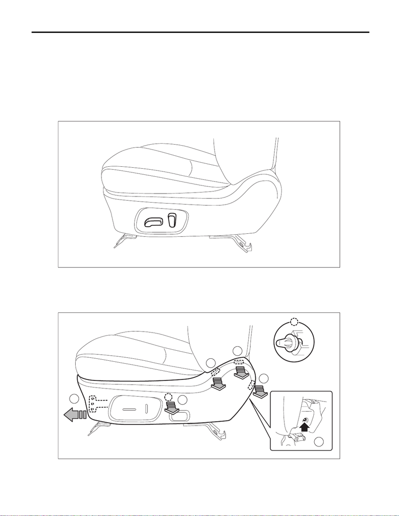

SE-39

Power Seat System

SEATS

4. Power Seat System

A: REMOVAL

CAUTION:

When removing the front seat, disconnect the ground cable from the battery before disconnecting

the side airbag module harness connector, and wait for 60 seconds before starting the operation.

1. POWER SEAT SWITCH

1) Remove the seat from vehicle. <Ref. to SE-9, REMOVAL, Front Seat.>

2) Remove the knob - power seat.

3) Remove the cover - hinge front seat OUT.

(1) Remove the screws in the rear section of the cover - hinge front seat OUT.

(2) Release the claw in the upper section of the cover - hinge front seat OUT.

(3) Remove the clip, and release the claws in the front section of the cover - hinge front seat OUT.

(4) Disconnect the power seat switch connector, and remove the cover - hinge front seat OUT.

SE-01336

SE-01669

4

3

1

2

2

2

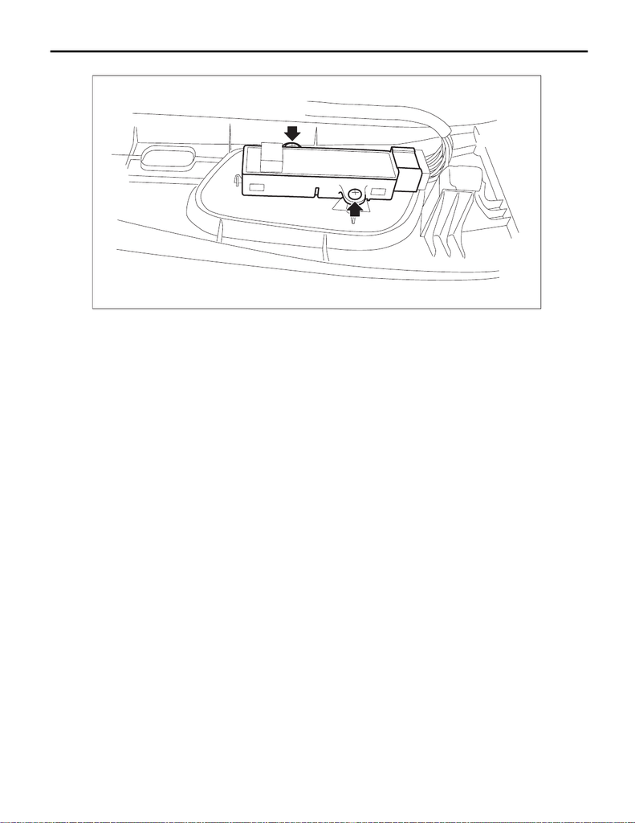

SE-40

Power Seat System

SEATS

4) Remove the screws to remove the power seat switch assembly.

B: INSTALLATION

1) Install the power seat switch assembly.

2) Install the cover - hinge front seat OUT.

3) Install the knob - power seat.

4) Install the seat assembly. <Ref. to SE-10, INSTALLATION, Front Seat.>

C: INSPECTION

1. WIRING DIAGRAM

Refer to “Power Seat” in WI section. <Ref. to WI-322, WIRING DIAGRAM, Power Seat System.>

SE-01338

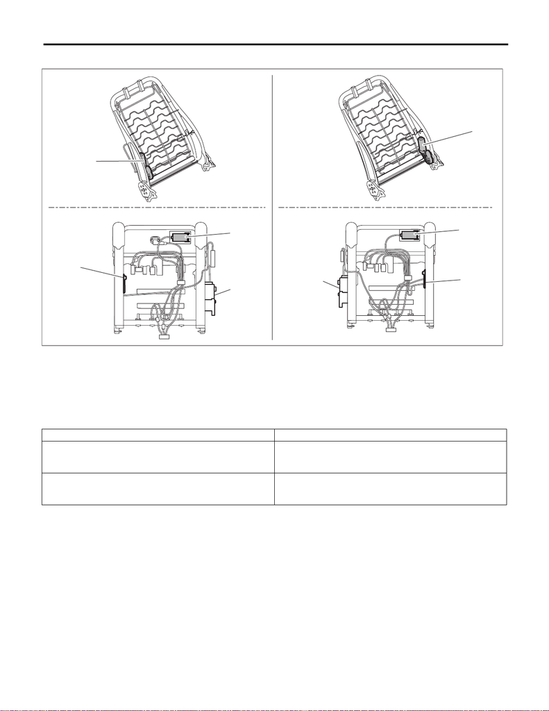

SE-41

Power Seat System

SEATS

2. NOTE

3. TROUBLE SYMPTOM

(A) Driver’s seat (B) Passenger’s seat

(a) Reclining motor (c) Tilt motor (d) Slide motor

(b) Lifter motor

Symptoms Criteria

All functions do not operate.

<Ref. to SE-43, ALL FUNCTIONS DO NOT OPERATE,

INSPECTION, Power Seat System.>

• Power seat switch

• Power seat harness

• Body harness

A part of function does not operate.

<Ref. to SE-43, SOME MOTORS DO NOT OPERATE,

INSPECTION, Power Seat System.>

• Power seat switch

• Power seat harness

• Relevant motor

SE-01682

(a)

(A) (B)

(a)

(b)

(d)

(c)

(d)

(b)

(c)

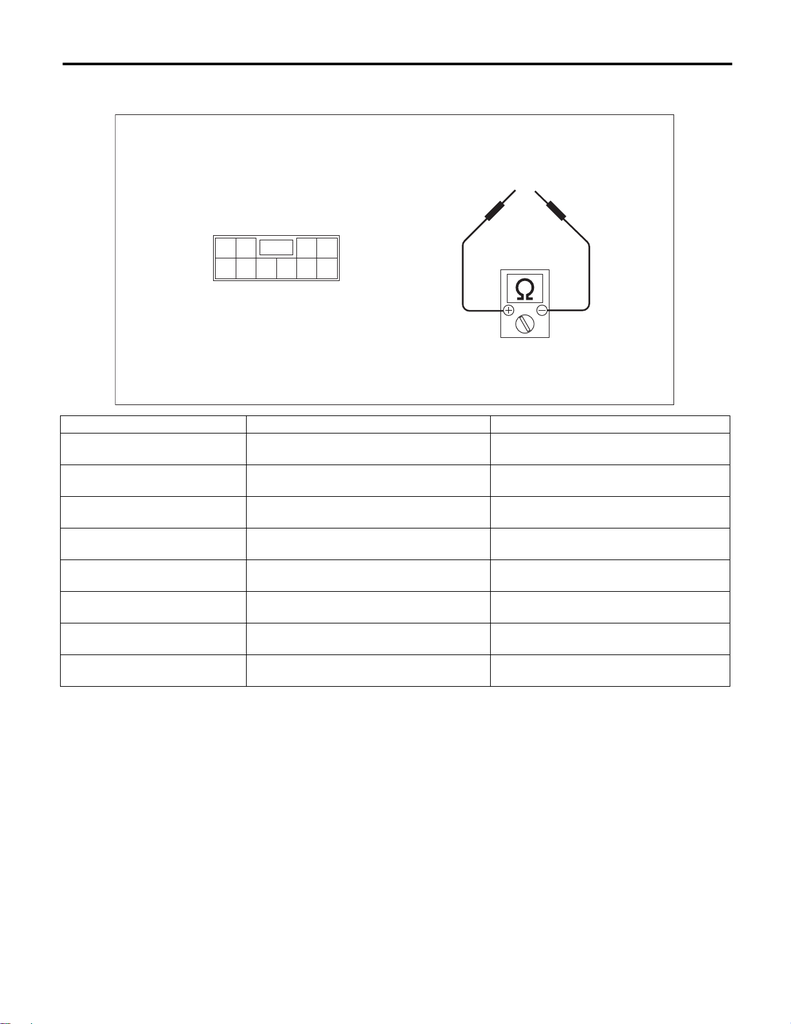

SE-42

Power Seat System

SEATS

4. CHECK POWER SEAT SWITCH

Measure resistance between terminals while operating each switch.

Replace the power seat switch if the inspection result is not within the standard value.

Switch position Terminal No. Standard

Slide forward

1 and 8

4 and 7

Less than 10 Ω

Slide rearward

1 and 7

4 and 8

Less than 10 Ω

Tilt up

1 and 3

2 and 4

Less than 10 Ω

Tilt down

1 and 2

3 and 4

Less than 10 Ω

Lifter up

1 and 6

4 and 9

Less than 10 Ω

Lifter down

1 and 9

4 and 6

Less than 10 Ω

Reclining forward

1 and 10

4 and 5

Less than 10 Ω

Reclining rearward

1 and 5

4 and 10

Less than 10 Ω

SE-01342

5

4

3

8

2

1

9

10

[figure not shown]

SE-43

Power Seat System

SEATS

5. ALL FUNCTIONS DO NOT OPERATE

6. SOME MOTORS DO NOT OPERATE

• Slide operation failure

Step Check Yes No

1 CHECK SEAT FUNCTIONS.

Operate each power seat switch and check that

each power seat function operates normally.

Does all function fail to oper-

ate?

Go to step 2. Check the motor

which does not

operate. <Ref. to

SE-43, SOME

MOTORS DO NOT

OPERATE,

INSPECTION,

Power Seat Sys-

tem.>

2 CHECK FUSE.

Check the power seat fuse inside the fuse box.

Is the fuse blown out? Replace the appro-

priate fuse.

Go to step 3.

3 CHECK POWER SUPPLY CIRCUIT.

1) Disconnect the connector of power seat

switch assembly.

2) Measure the voltage between harness con-

nector and chassis ground.

Connector & terminal

(R200) No. 1 (+) — Chassis ground (–):

Is the voltage 10 V or more? Go to step 4. Check body har-

ness.

switch harness connector and chassis ground.

Is the resistance less than 10

Ω?

Replace the power

seat switch assem-

bly.

Check body har-

ness.

Step Check Yes No

1 CHECK SWITCH.

1) Disconnect the connector of power seat

switch assembly.

2) Measure the resistance between connector

terminals when moving the switch to slide for-

ward and slide backward. <Ref. to SE-42,

CHECK POWER SEAT SWITCH, INSPEC-

TION, Power Seat System.>

Is the inspection result normal? Go to step 2. Replace the power

seat switch assem-

bly.

2 CHECK HARNESS.

1) Disconnect the power seat switch connector

and slide motor connector.

2) Measure the resistance between power

seat switch connector and slide motor connec-

tor.

Connector & terminal

(R200) No. 8 — (R202) No. 5:

(R200) No. 7 — (R202) No. 1:

Is the resistance less than 10

Ω?

Go to step 3. Check power seat

harness.

3 CHECK SLIDE MOTOR.

1) Connect the power seat switch connector

and slide motor connector.

2) Apply 12 V to the slide motor and check the

motor rotation.

Connector & terminal

(R202) No. 5 (+) — (R202) No. 1 (–):

(R202) No. 1 (+) — (R202) No. 5 (–):

Does the motor rotate nor-

mally?

Check for tempo-

rary poor contact

or mechanical

trouble in slide rail.

Slide motor prob-

lem. Replace the

seat cushion frame

assembly.

[figure not shown]

SE-44

Power Seat System

SEATS

• Malfunction of tilt operation

• Malfunction of lifter operation

Step Check Yes No

1 CHECK SWITCH.

1) Disconnect the connector of power seat

switch assembly.

2) Measure the resistance between connector

terminals when moving the switch to tilt up and

tilt down. <Ref. to SE-42, CHECK POWER

SEAT SWITCH, INSPECTION, Power Seat

System.>

Is the inspection result normal? Go to step 2. Replace the power

seat switch assem-

bly.

2 CHECK HARNESS.

1) Disconnect the power seat switch connector

and tilt motor connector.

2) Measure the resistance between power

seat switch connector and tilt motor connector.

Connector & terminal

(R200) No. 3 — (R203) No. 4:

(R200) No. 2 — (R203) No. 6:

Is the resistance less than 10

Ω?

Go to step 3. Check power seat

harness.

3 CHECK TILT MOTOR.

1) Connect the power seat switch connector

and tilt motor connector.

2) Apply 12 V to the tilt motor and check the

motor rotation.

Connector & terminal

(R203) No. 4 (+) — (R203) No. 6 (–):

(R203) No. 6 (+) — (R203) No. 4 (–):

Does the motor rotate nor-

mally?

Check for tempo-

rary poor contact

or mechanical

trouble in tilt mech-

anism.

Tilt motor problem.

Replace the seat

cushion frame

assembly.

Step Check Yes No

1 CHECK SWITCH.

1) Disconnect the connector of power seat

switch assembly.

2) Measure the resistance between connector

terminals when moving the switch to lifter up

and lifter down. <Ref. to SE-42, CHECK

POWER SEAT SWITCH, INSPECTION, Power

Seat System.>

Is the inspection result normal? Go to step 2. Replace the power

seat switch assem-

bly.

2 CHECK HARNESS.

1) Disconnect the power seat switch connector

and lifter motor connector.

2) Measure the resistance between power

seat switch connector and lifter motor connec-

tor.

Connector & terminal

(R200) No. 6 — (R204) No. 6:

(R200) No. 9 — (R204) No. 4:

Is the resistance less than 10

Ω?

Go to step 3. Check power seat

harness.

3 CHECK LIFTER MOTOR.

1) Connect the power seat switch connector

and lifter motor connector.

2) Apply 12 V voltage to the lifter motor and

check the motor rotation.

Does the motor rotate nor-

mally?

Check for tempo-

rary poor contact

or mechanical

trouble in lifter

mechanism.

Lifter motor prob-

lem. Replace the

seat cushion frame

assembly.

[figure not shown]

SE-45

Power Seat System

SEATS

• Malfunction of reclining operation

Step Check Yes No

1 CHECK SWITCH.

1) Disconnect the connector of power seat

switch assembly.

2) Measure the resistance between connector

terminals when moving the switch to reclining

forward and reclining backward. <Ref. to SE-42,

CHECK POWER SEAT SWITCH, INSPEC-

TION, Power Seat System.>

Is the inspection result normal? Go to step 2. Replace the power

seat switch assem-

bly.

2 CHECK HARNESS.

1) Disconnect the power seat switch connector

and reclining motor connector.

2) Measure the resistance between power

seat switch connector and reclining motor con-

nector.

Connector & terminal

(R200) No. 10 — (R201) No. 6:

(R200) No. 5 — (R201) No. 4:

Is the resistance less than 10

Ω?

Go to step 3. Check power seat

harness.

3 CHECK RECLINING MOTOR.

1) Connect the power seat switch connector

and reclining motor connector.

2) Apply 12 V voltage to the reclining motor

and check the motor rotation.

Connector & terminal

(R201) No. 6 (+) — (R201) No. 4 (–):

(R201) No. 4 (+) — (R201) No. 6 (–):

Does the motor rotate nor-

mally?

Check for tempo-

rary poor contact

or mechanical

trouble in reclining

hinge.

Reclining motor

problem. Replace

the backrest frame

assembly.